# R в социологических исследованиях

Автор

Дарья Омельченко

# В качестве предисловия…

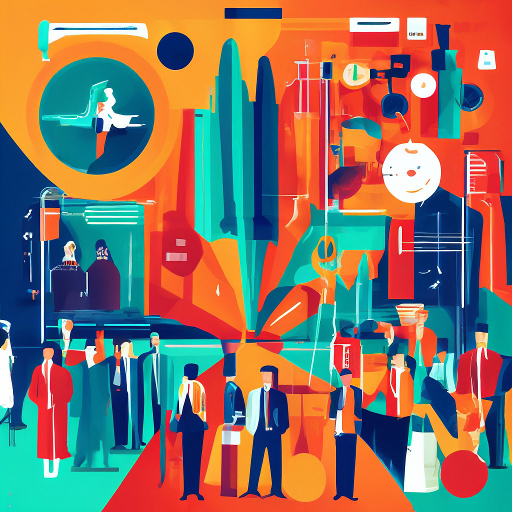

Это электронное пособие создано для магистрантов, обучающихся по направлению 39.04.01 «Социология», программа «Цифровые методы анализа и визуализации данных», и содержит обучающие материалы по дисциплине «Анализ данных в R», однако, возможно, оно будет интересно всем, кто хотел бы начать использовать R в качестве аналитического инструмента и выйти за рамки классических пакетов анализа и обработки данных, таких, например, как SPSS.

Цель курса, равно как и настоящего издания, состоит в том, чтобы познакомить слушателей с основами языка, ключевыми командами, функциями и библиотеками, которые могут быть полезными в процессе организации, сбора данных и анализа результатов социологических исследований, и особенно - представления и распространения результатов.

Хотя R это язык программирования, мы в ходе освоения курса мы практически не будем использовать его в этом качестве, наша основная задача - стать уверенными пользователями R и использовать его для решения профессиональных социологических и учебных задач.

Чему мы научимся:

- Работать с различными структурами данных, испортировать и экспортировать данные в различных форматах;
- Создавать несложные функции и понимать документацию к библиотекам;
- Модифицировать данные для исследовательских задач - создавать новые переменные, разъединять и соединять массивы;
- Анализировать результаты количественных социологических исследований и проверять статистические гипотезы, как простые, так и сложные, применять многомерные методы анализа;
- Создавать визуализации на основе результатов исследования, создавать интерактивные отчеты и простые приложения, демонстрирующие возможности R в распространении научных публикаций.

Что осталось за кадром?

- Мы не будем учиться создавать библиотеки и писать сложные функции;
- Мы не сможем в полной мере охватить все методы анализа;
- Вряд ли получится разобрать все инструменты для визуализации;
- За пределами нашего внимания останутся и возможности R по созданию сайтов, блогов и книг.

Однако, и того, что запланировано, представляется хватит, для того, чтобы полюбить R и стать частью сообщества исследователей, использующих R в своей повседневной жизни для решения рутинных задач и поиска инновационных решений.

Мы начинаем!